# Wizualizacja danych I

16-05-2026

## O mnie

Michał Burdukiewicz:

- bioinformatyk (Uniwersytet Medyczny w Białymstoku, Vilnius University),
- lider grupy badawczej BioGenies (biogenies.info),
- 16 lat doświadczenia z R,
- Stowarzyszenie Wrocławskich Użytkowników R (stwur.pl),
- Fundacja Why R? (whyr.pl).

Materiały: https://github.com/michbur/WizualizacjaDanych2025-2026L

Riseup: https://pad.riseup.net/p/WWD-tmp

Mail: michalburdukiewicz@gmail.com

## Literatura

- Wilke, C. (2020). Podstawy wizualizacji danych. Zasady tworzenia atrakcyjnych wykresów. (https://clauswilke.com/dataviz/)
- Wilkinson, L. (2005). The Grammar of Graphics.
- Cairo, A. (2019). How Charts Lie: Getting Smarter about Visual Information.
- [Engebretsen M., Kennedy H. (2020). Data Visualization in Society](https://www.aup.nl/en/book/9789048543137/data-visualization-in-society).
- https://data.europa.eu/apps/data-visualisation-guide/.

## Praktyczny R z elementami bioinformatyki

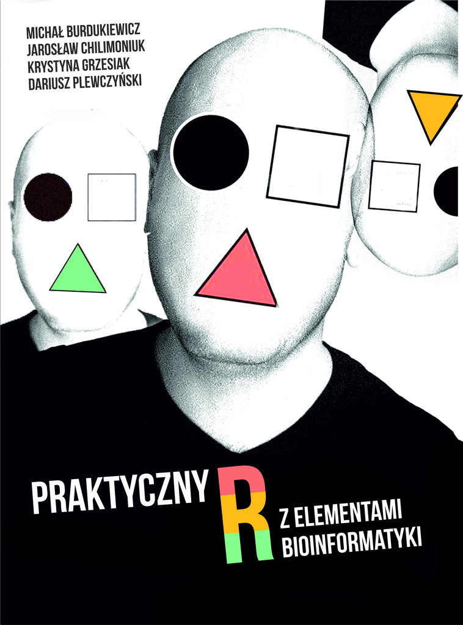

W księgarniach pod na początku 2026.

## Plan spotkań

1. Czym są wizualizacje danych?
2. Gramatyka grafiki.
3. Błędy w wizualizacjach danych.
4. Narzędzia do wizualizacji danych.
5. Efektywne projektowanie dashboardów.
6. Zaaawansowane wizualizacje danych.

## Plan spotkań

1. **Czym są wizualizacje danych?**
2. **Gramatyka grafiki.**
   - Praca w grupach.
3. **Błędy w wizualizacjach danych.**
   - Praca w grupach.
4. **Narzędzia do wizualizacji danych.**
   - Praca w grupach.
5. Efektywne projektowanie dashboardów.
6. Zaaawansowane wizualizacje danych.

## Historia wizualizacji danych

## Florence Nightingale

[figure not shown]

## Standardy

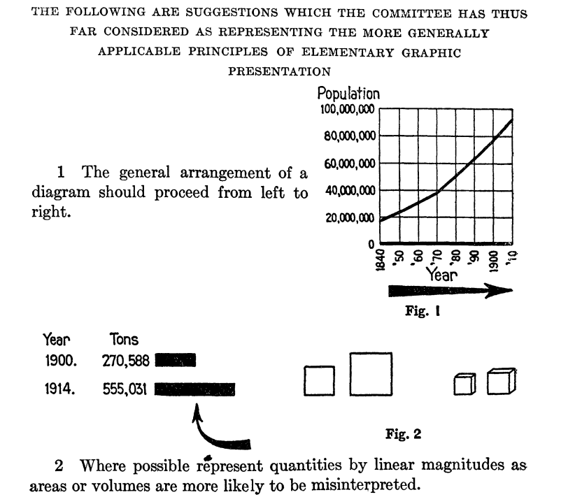

Joint Committee on Standards for Graphic Presentation (1915). **Standards for Graphic Presentation**. Publications of the American Statistical Association 14, 790–797.

## Czym są wizualizacje danych?

> **…(a) is based on qualitative or quantitative data and (b) results in an image that is representative of the raw data, which is (c) readable by viewers and supports exploration, examination, and communication of the data…**

\(~\)

Źródło: Tarek Azzam, Stephanie Evergreen, Amy A. Germuth, and Susan J. Kistler. Data visualization and evaluation. New Directions for Evaluation, 2013(139):7 32, 2013.

## Czym są wizualizacje danych?

> **…involves presenting data in graphical or pictorial form which makes the information easy to understand…**

\(~\)

Źródło: Matthew Sadiku, Adebowale Shadare, Sarhan Musa, Cajetan Akujuobi, and Roy Perry. Data visualization. International Journal of Engineering Research and Advanced Technology (IJERAT), 12:2454 6135, 12 2016.

## Czym są wizualizacje danych?

Wizualizacja danych to forma komunikacji. Tak jak każdy komunikat, wykresy muszą być przede wszystkim zrozumiałe dla odbiorcy.

## Rodzaje wizualizacji

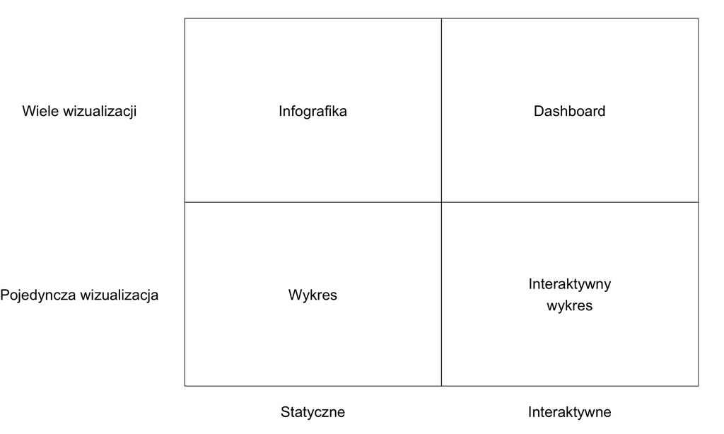

## Wizualizacja statyczna

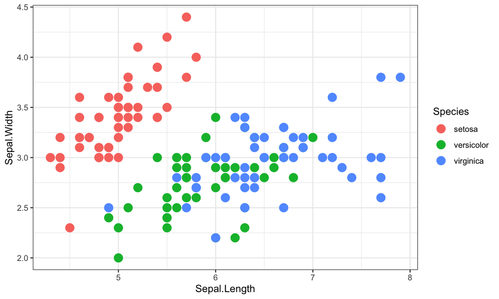

## 3D

[figure not shown]

Wykresy 3D w **R**: https://github.com/tylermorganwall/rayshader

## Infografiki

Inspiracje: [VennGage](https://venngage.com/)

[figure not shown]

## Wizualizacje interaktywne

[interactive chart not shown]

## Dashboardy

[figure not shown]

## Gramatyka grafiki

## Gramatyka grafiki

Gramatyka grafiki (grammar of graphics): ustrukturyzowany opis wizualizacji danych.

Wilkinson, L. (2005). The Grammar of Graphics (New York: Springer-Verlag).

## Gramatyka grafiki

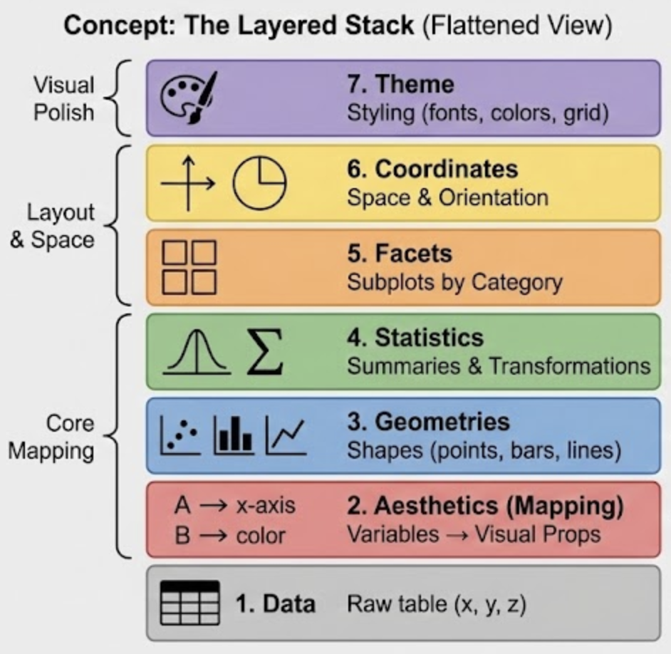

## Dane

| Sepal.Length | Sepal.Width | Petal.Length | Petal.Width | Species |
| --- | --- | --- | --- | --- |
| 5.1 | 3.5 | 1.4 | 0.2 | setosa |
| 4.9 | 3.0 | 1.4 | 0.2 | setosa |
| 4.7 | 3.2 | 1.3 | 0.2 | setosa |
| 4.6 | 3.1 | 1.5 | 0.2 | setosa |
| 5.0 | 3.6 | 1.4 | 0.2 | setosa |
| 5.4 | 3.9 | 1.7 | 0.4 | setosa |

## Atrybuty wizualne

Atrybuty wizualne (aesthetics): mapowanie danych do osi, kolorów, kształtów.

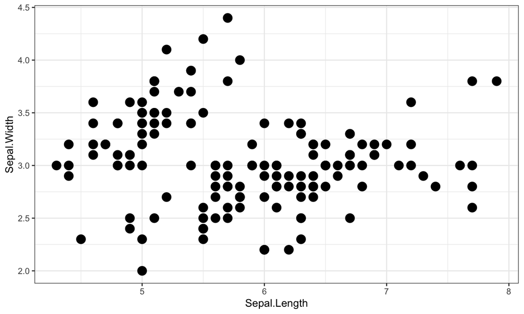

## Atrybuty wizualne

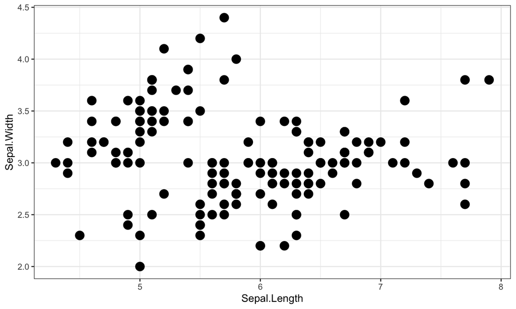

**Oś X:** Sepal.Length. **Oś Y:** Sepal.Width.

## Atrybuty wizualne

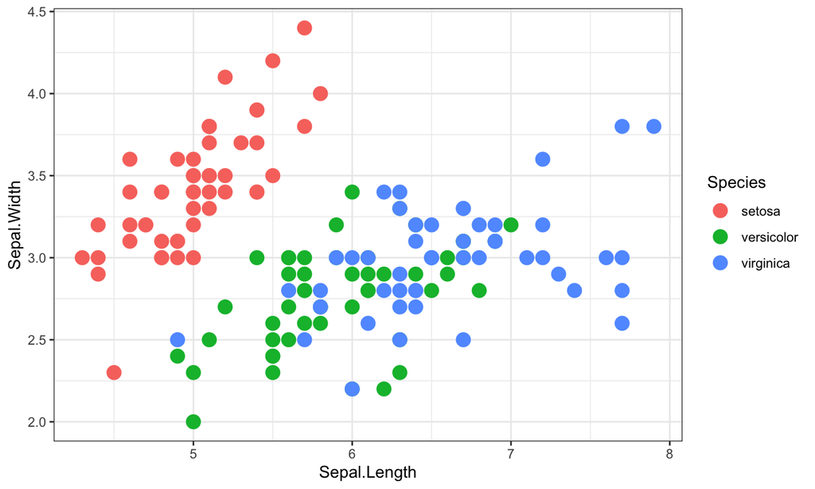

**Oś X:** Sepal.Length. **Oś Y:** Sepal.Width. **Kolor:** Species.

## Atrybuty wizualne

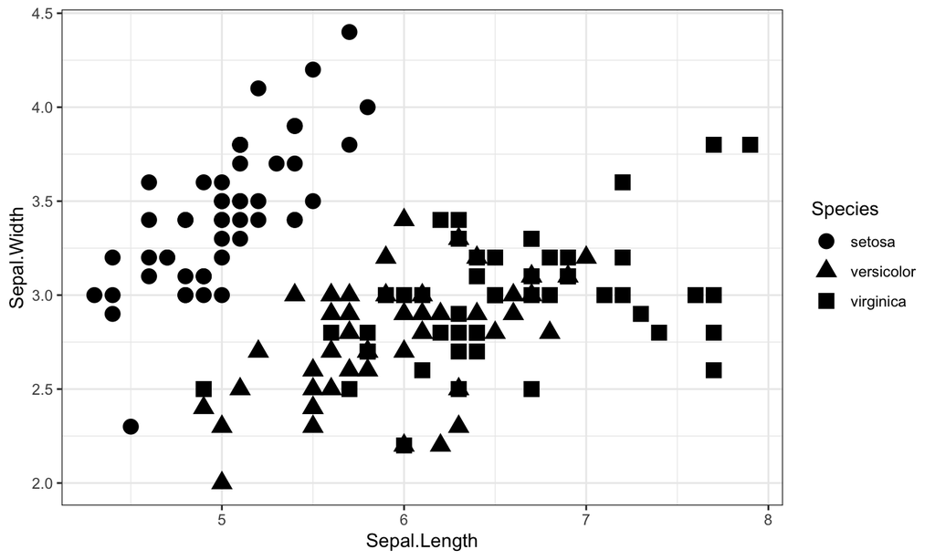

**Oś X:** Sepal.Length. **Oś Y:** Sepal.Width. **Kształt:** Species.

## Geometrie

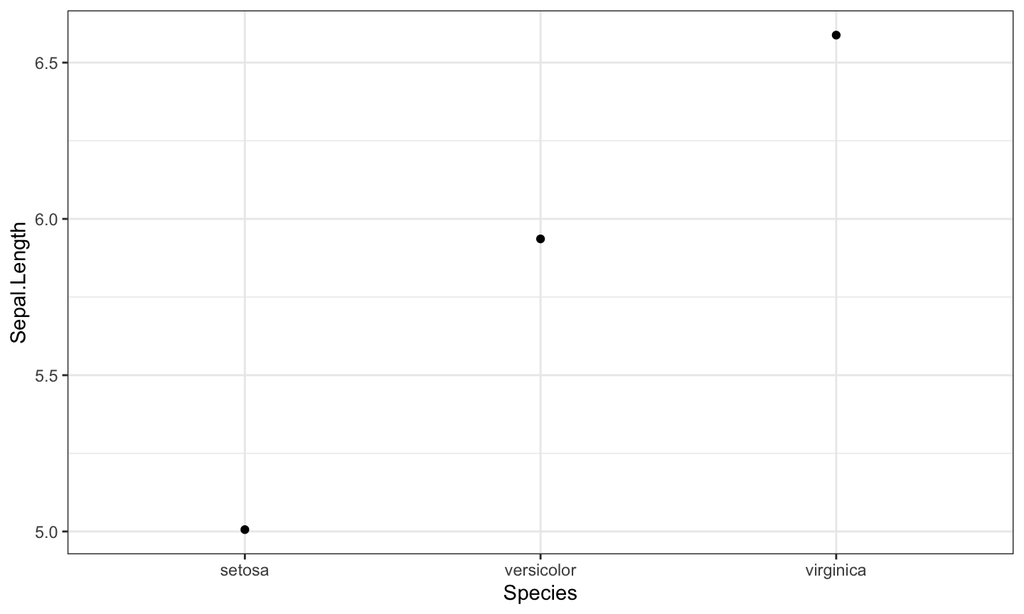

Geometrie: obiekty reprezentujące dane.

## Geometrie

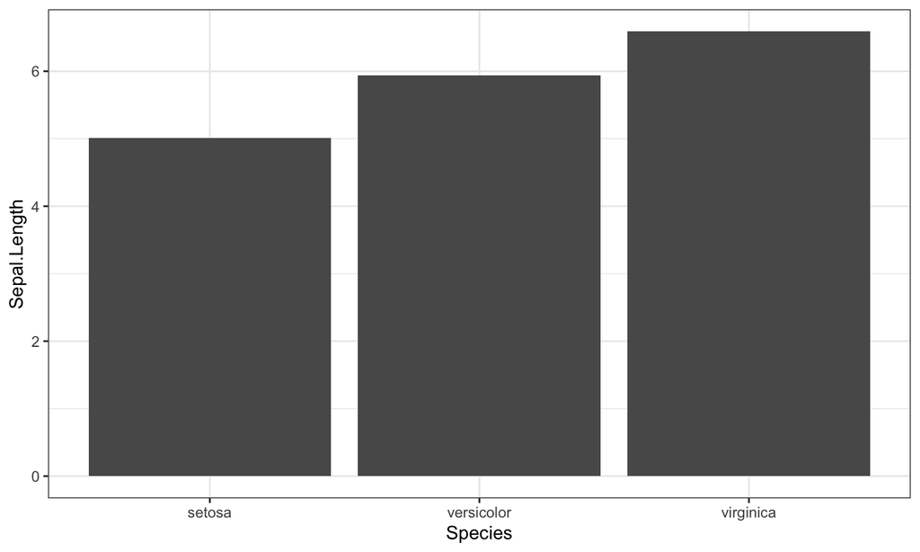

## Fasety

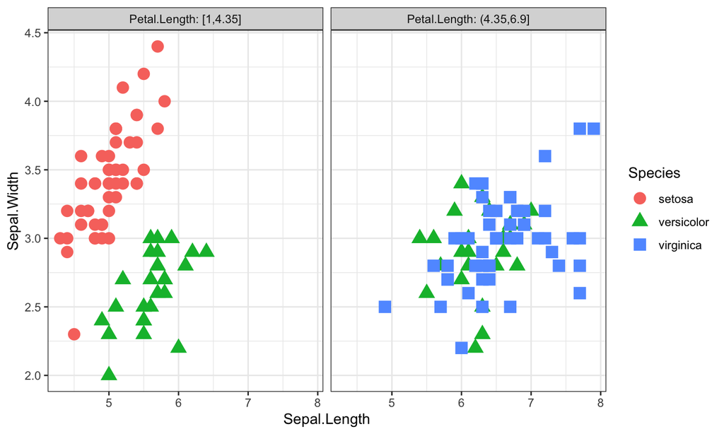

Dzielenie wykresu na podwykresy w zależności od poziomu zmiennej dyskretnej.

## Fasety

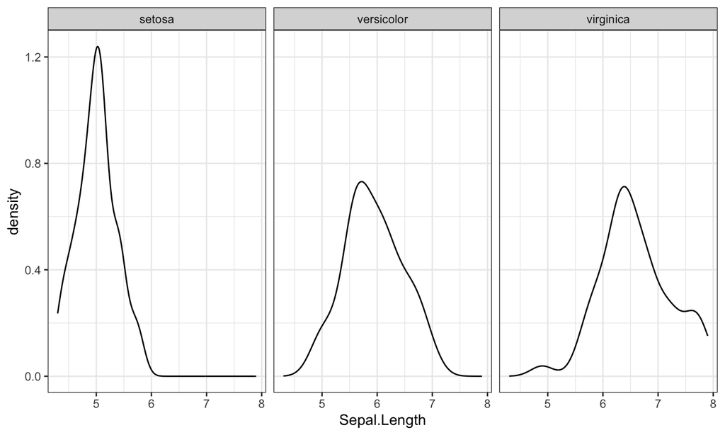

## Fasety

Wykres poprzedni bez fasetowania.

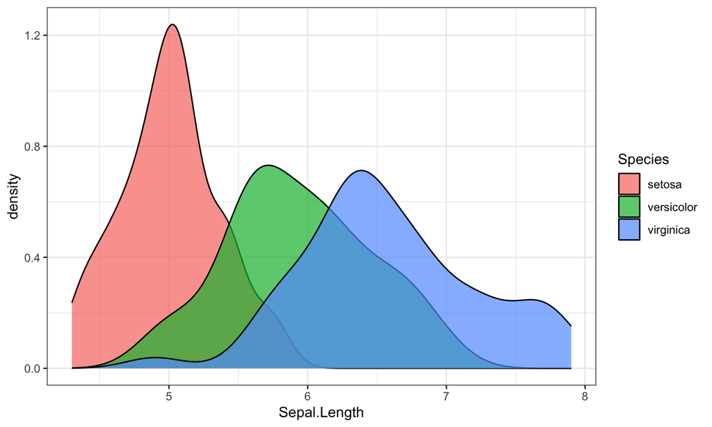

## Fasety

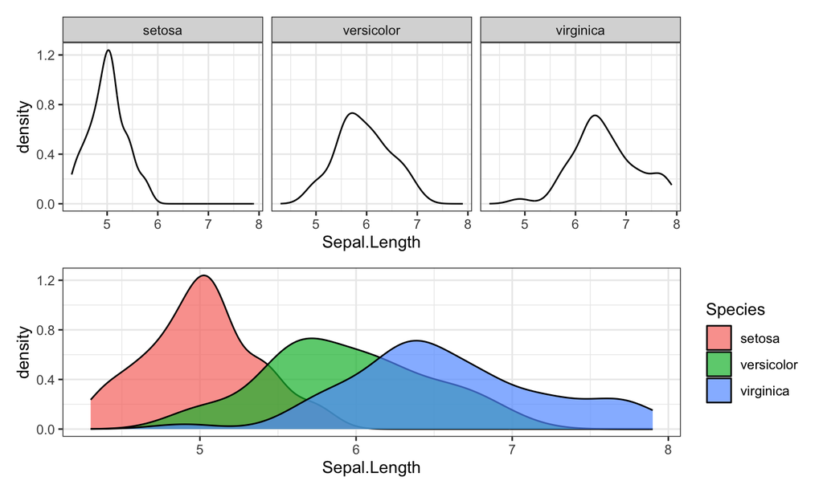

## Statystyki

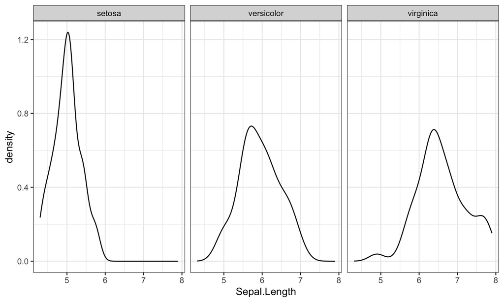

Transformacje danych w celu przypisania ich do atrybutów wizualnych.

## Statystyki

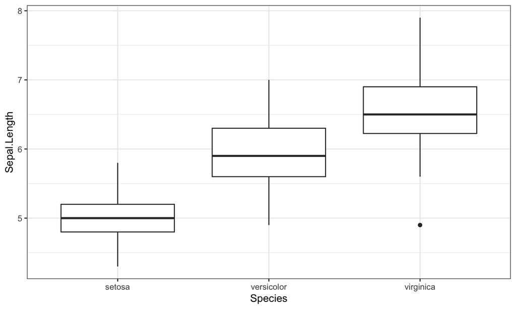

## Statystyki

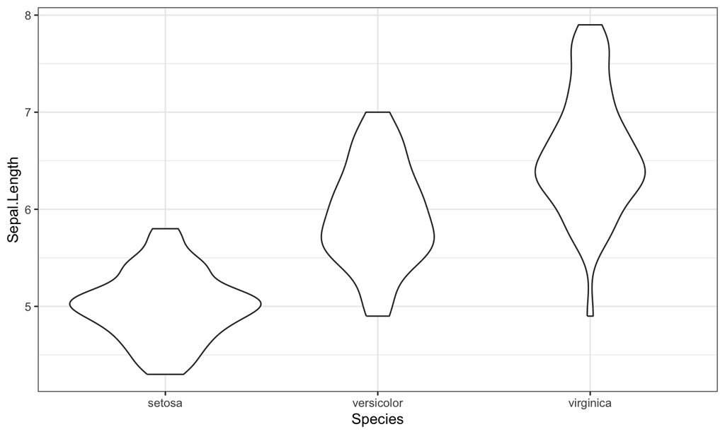

## Statystyki

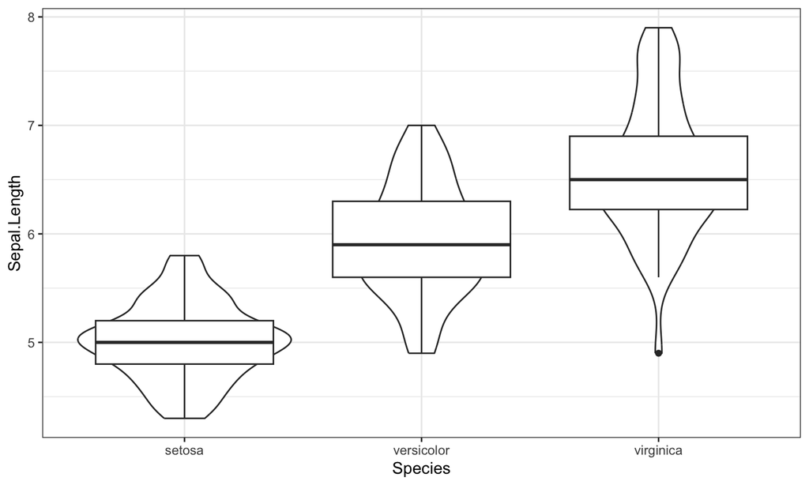

## Statystyki

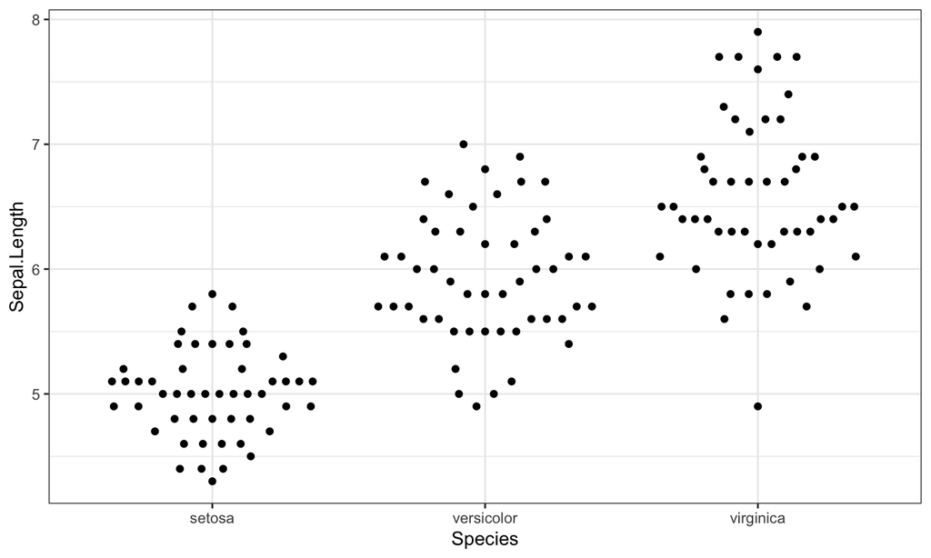

## Statystyki

## Statystyki

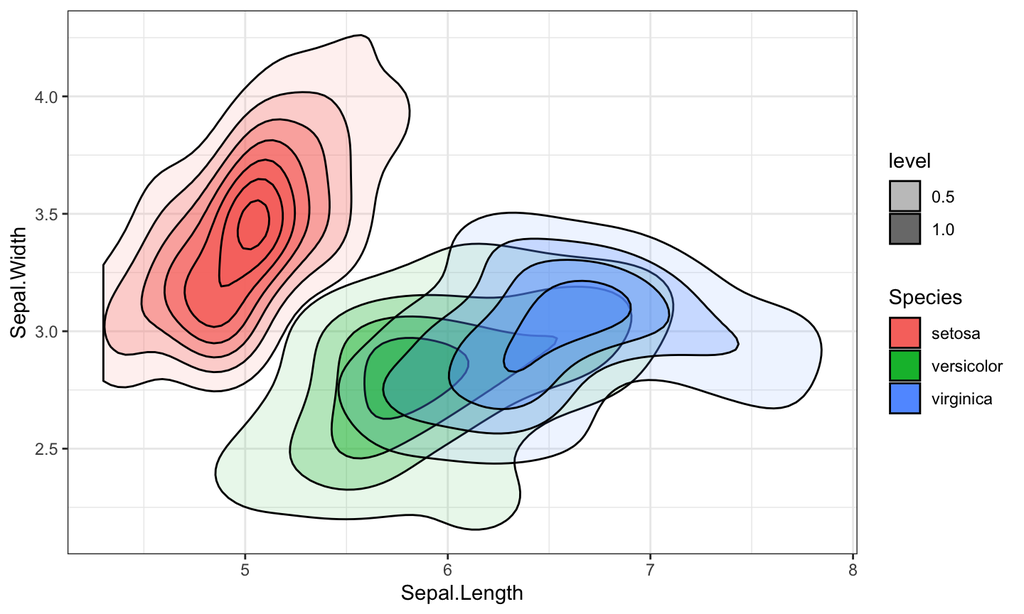

## Koordynaty

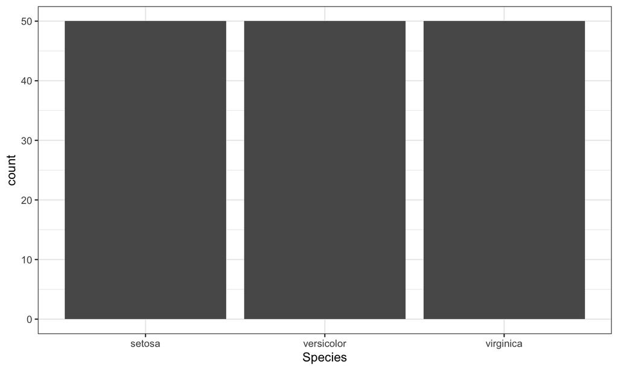

## Koordynaty

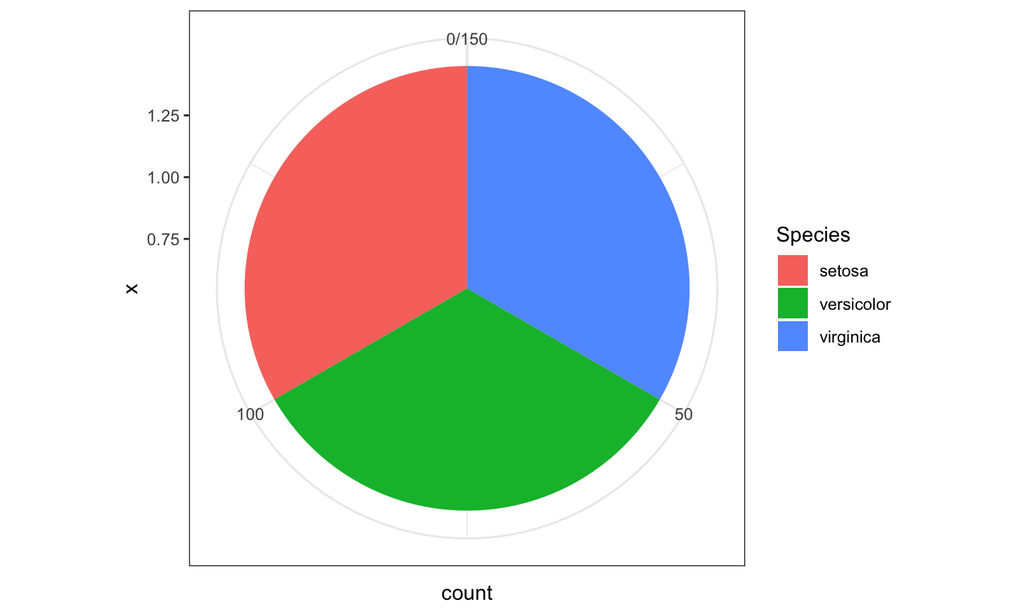

## Motyw

## Motyw

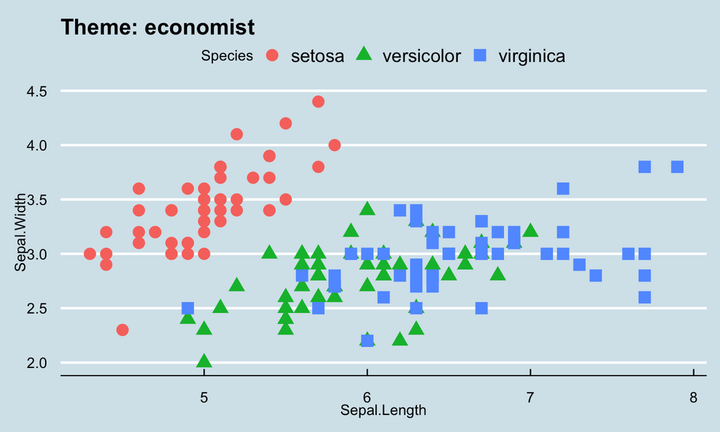

## Motyw

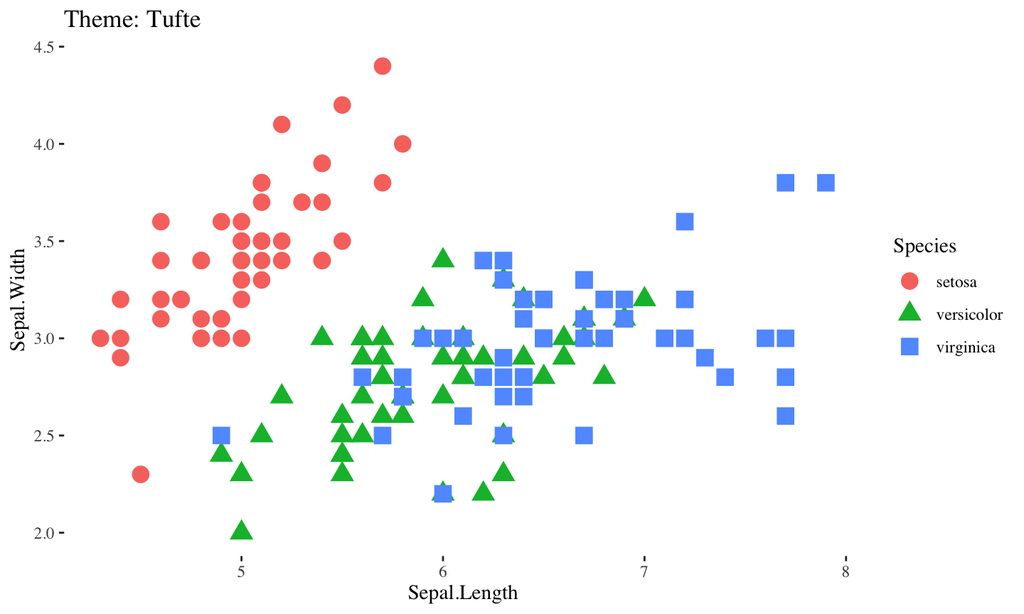

## Motyw

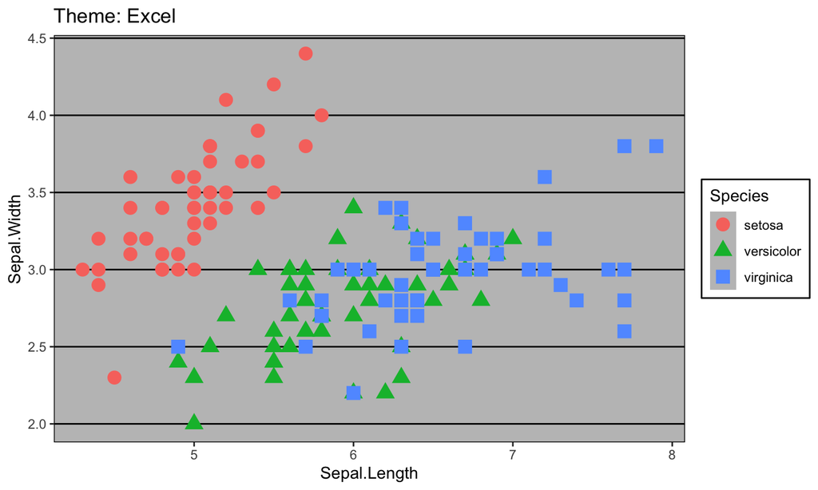

## Stylizowanie wizualizacji

1. Czcionki.
2. Dodatkowe elementy graficzne.

## Czcionki

1. Czcionka do tytułów/nagłówków.
2. Treść dokumentu.
3. Wyróżnianie treści.

## Czcionki

[figure not shown]

## Czcionki

Czcionki wykorzystywane przez Tableau są tak dobrane, aby zapewnić maksymalną czytelność przy małych rozmiarach.

[figure not shown]

## Grafiki

Elementy graficzne nawiązujące do treści wzmacniają przekaz i pozwalają lepiej zrozumieć dane.

## Grafiki

[figure not shown]

## Gramatyka grafiki

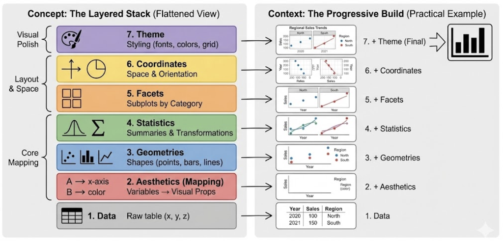

## Gramatyka grafiki

| Nazwa | Przykłady |
| --- | --- |
| Dane (data) |  |
| Atrybuty wizualne (aesthetics) | Osie, kolory, kształty, typy linii |
| Geometrie (geometries) | Linie, słupki, punkty |
| Fasety (facets) | Podrysunki tworzone na podstawie dyskretnych zmiennych |
| Statystyki (statistics) | Średnie, mediany, kwantyle. |
| Koordynaty (coordinates) | Kartezjański, polarny |
| Motyw (theme) | Wygląd rysunku |

## Błąd dopasowania

Błąd dopasowania to sytuacja, w której zastosowane elementy gramatyki grafiki nie wspierają porównań wymaganych przez cel wykresu, przez co wizualizacja nie realizuje swojego zadania poznawczego.

Przykłady błędów dopasowania:

- statystyka agreguje w sposób, który zaciera porównanie wymagane przez cel;
- atrybut wizualny koduje zmienną, która nie jest istotna z punktu widzenia celu wykresu.

## Przykłady

```r
dat <- read.csv("./data/polish-driver-license.csv")
kable(dat[1L:3, ])
```

| voivodeship | gender | age | count | year | month |
| --- | --- | --- | --- | --- | --- |
| WOJ. DOLNOŚLĄSKIE | K | 16 | 3 | 2019 | 8 |
| WOJ. DOLNOŚLĄSKIE | K | 17 | 3 | 2019 | 8 |
| WOJ. DOLNOŚLĄSKIE | K | 18 | 390 | 2019 | 8 |

- **voivodeship**: województwo
- **gender**: płeć
- **age**: wiek
- **count**: liczba uzyskanych praw jazdy
- **year**: rok
- **month**: miesiąc

## Zadanie 1

W podgrupach opisać wykresy wykorzystując gramatykę grafiki. Skupiamy się na:

- atrybutach wizualnych
- geometriach
- facetach
- statystykach.

Każdą wizualizację podsumować jednym największym błędem dopasowania.

Riseup: https://pad.riseup.net/p/WWD-tmp

Plik: examples.html.

## Błędy w wizualizacjach

## Rodzaje złych wizualizacji

1. Fałszywe (przedstawiające fałszywe informacje).
2. Mylące (przedstawiające fałszywie rzeczywiste informacje).

## Złe wizualizacje

[figure not shown]

Trudne porównania - niewłaściwie wybrana metoda wizualizacja.

## Złe wizualizacje

[figure not shown]

Niewłaściwie wybrana metoda wizualizacji.

## Trzeci wymiar

[figure not shown]

Source: https://clauswilke.com/dataviz/

## Wykresy kołowe

[figure not shown]

## Wykresy kołowe

[figure not shown]

## Ucięte osie

[figure not shown]

## Ucięte osie

[figure not shown]

## Ucięte osie

[figure not shown]

## Kolory

[figure not shown]

## Kolory

Kolory mogą nawiązywać do treści wizualizacji…

[figure not shown]

## Kolory

… ale schemat kolorystyczny powinien być stosowany konsekwentnie.

[figure not shown]

## Kolory

[figure not shown]

Źródło: http://www.asawicki.info/

## Kolory

[figure not shown]

Źródło: http://www.asawicki.info/

## Kolory

[figure not shown]

Źródło: http://www.asawicki.info/

## Widzenie barwne

https://www.color-blindness.com/coblis-color-blindness-simulator/

## Kolory

Tableau domyślnie dobiera palety kolorów (zarówno ilościowe jak i kategoryczne), które są łatwo rozróżnialne również dla osób z zaburzeniami widzenia barwnego.

## Kolory

https://colorbrewer2.org/: narzędzie do generowania palet kolorów.

## Prostota

Nadmiar stylizacji wykresu może zmniejszać czytelność wykresu.

## Prostota

[figure not shown]

## Prostota

[figure not shown]

## Prostota

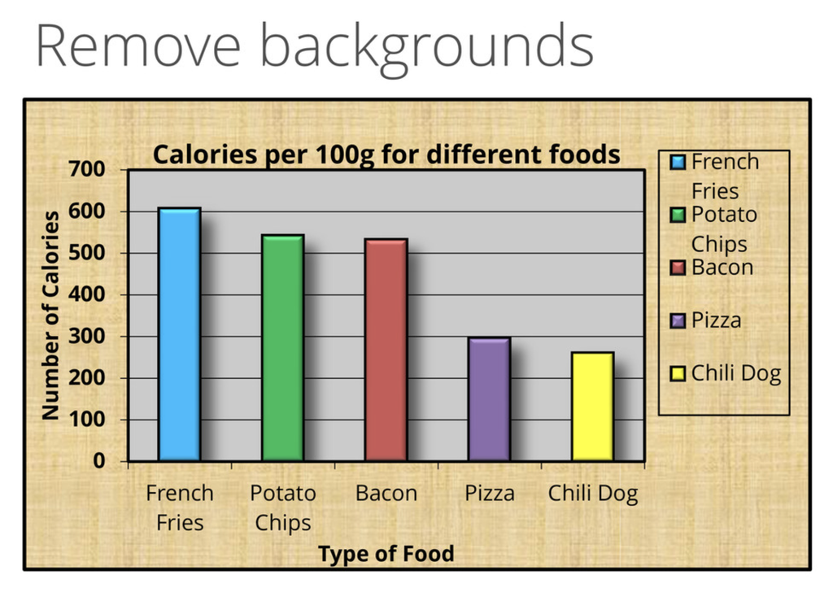

Źródło: [Joey Cherdarchuk](https://speakerdeck.com/player/87bb9f00ec1e01308020727faa1f9e72)

## Układ treści

[figure not shown]

## Wizualizacje i prawda

[figure not shown]

How to Lie with Statistics, Darrell Huff

## Zadanie 2

W podgrupach zaproponować poprawiony wykres wykorzystując gramatykę grafiki. Przy każdym elemencie gramatyki grafiki wyjaśnić dlaczego wspiera cel wizualizacji.

Riseup: https://pad.riseup.net/p/WWD-tmp

Plik: examples.html.

## Narzędzia do wizualizacji

## Narzędzia

1. Programistyczne (R, Python, JavaScript)
2. Programy graficzne (Inkscape).
3. Programy przeznaczone do wizualizacji danych i budowy dashboardów (Tableau).

## Podział narzędzi do wizualizacji danych

Deklaratywne:

- zadanie: warunki jakie musi spełniać wizualizacja,
- jak wizualizacja jest wykonywana jest rozstrzygane wewnętrznie i niezależnie od użytkownika,
- oddzielenie specyfikacji od wykonania.

Imperatywne:

- zadanie: krok po kroku jak stworzyć wizualizację,
- użytkownik w pełni kontroluje każdy detal wizualizacji,
- jeśli warunki jakie musi spełniać wizualizacja zmienią się nawet odrobinę, instrukcja tworzenia może się zmienić znacząco.

## Języki wizualizacji danych

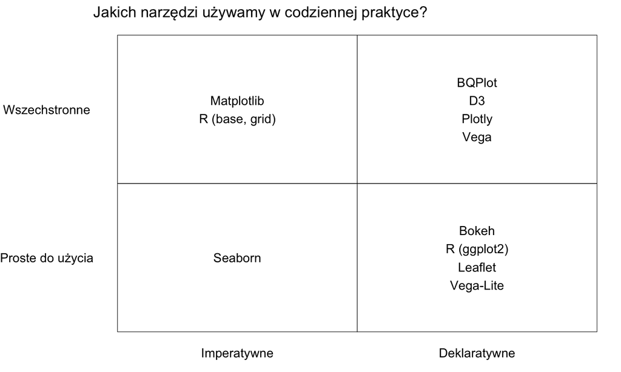

## Wywołanie deklaratywne

```r
library(ggplot2)

ggplot(iris, aes(x = Sepal.Length, y = Petal.Length)) +
  geom_point()
```

## Wywołanie deklaratywne

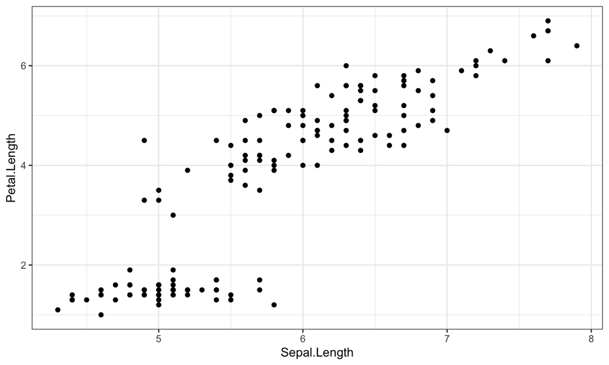

## Wywołanie imperatywne

```r
library(grid)

grid.newpage()

pushViewport(plotViewport(margins = c(5, 5, 5, 5)))
pushViewport(dataViewport(xscale = range(iris[["Sepal.Length"]]),
                          yscale = range(iris[["Petal.Length"]])))

grid.xaxis()
grid.yaxis()

grid.points(x = iris[["Sepal.Length"]],
            y = iris[["Petal.Length"]],
            default.units = "native",
            pch = 16)
```

## Wywołanie imperatywne

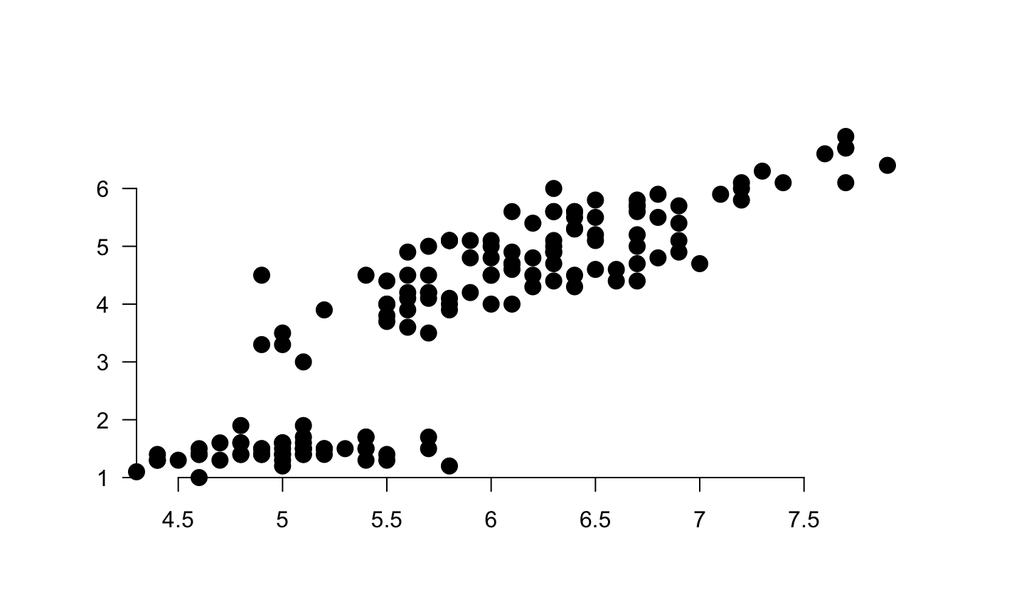

## Języki wizualizacji danych

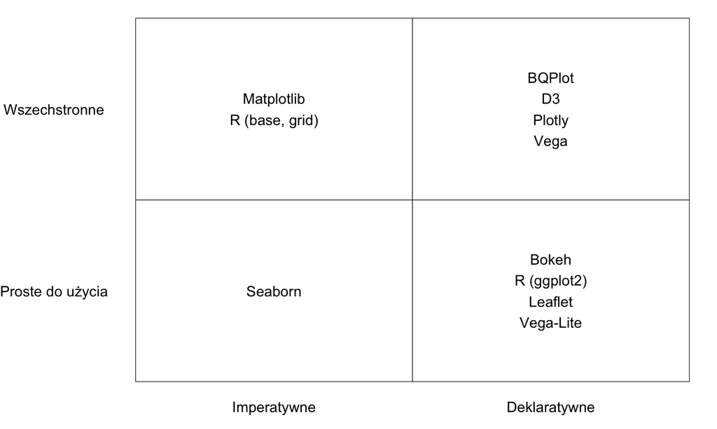

Lista narzędzi do wizualizacji danych: W1-addendum.html.

## Domyślne ustawienia narzędzi

Domyślne ustawienia to wbudowane decyzje o wyglądzie wykresu podjęte przez autorów danego narzędzia. Mają za zadanie przyśpieszyć tworzenie zrozumiałych wykresów, ale czasami mogą prowadzić do błędów.